# null

# Interaction of Age

Exploring the significance of age on the income gap between men and women reveals some interesting findings. Below is the table showing the coefficients of linear regression modeling income as a linear function of gender interacting with age.

|  | Estimate | Std. Error | t value | Pr(>\|t\|) |
| --- | --- | --- | --- | --- |
| (Intercept) | 52929.256 | 21438.355 | 2.469 | 0.014 |
| sexMale | -95028.953 | 30061.056 | -3.161 | 0.002 |
| current.age | -303.896 | 558.823 | -0.544 | 0.587 |
| sexMale:current.age | 2893.822 | 783.541 | 3.693 | 0.000 |

As can be seen in the table, the model determined that for females, every year of age corellated with an decrease in income by $303.90. However, the p-value for this correlation was approximately 0.5866, indicating that this correlation was not significant. On the other hand, the model determined that for males, every year of age corellated with an increase in income by $2,589.92. This correlation was significant, as indicated by the p-value of approximately 2^{-4}. While the interaction of age was not significant for females, the graph below illustrates that overall, age was significant in the income gap between men and women.

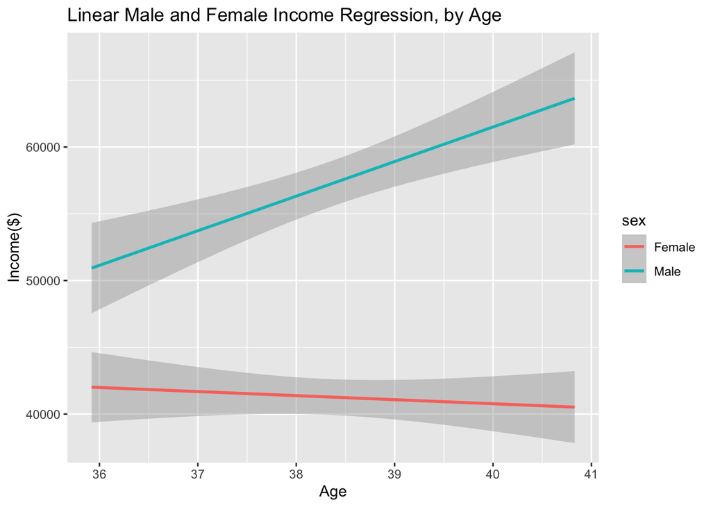

Also, we wanted to explore how the model was fit to the data, so we ran diagnostic plots as follows

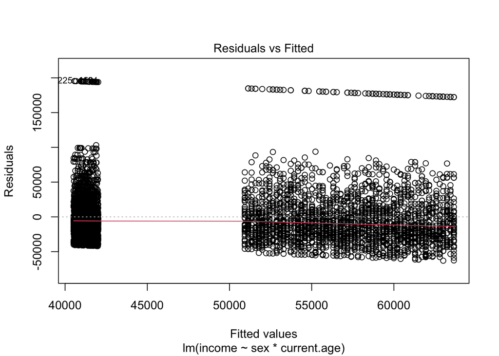

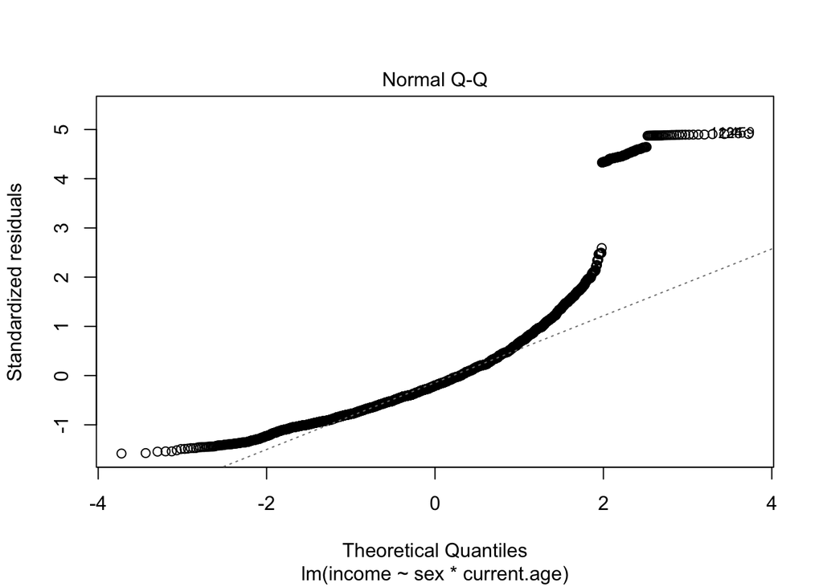

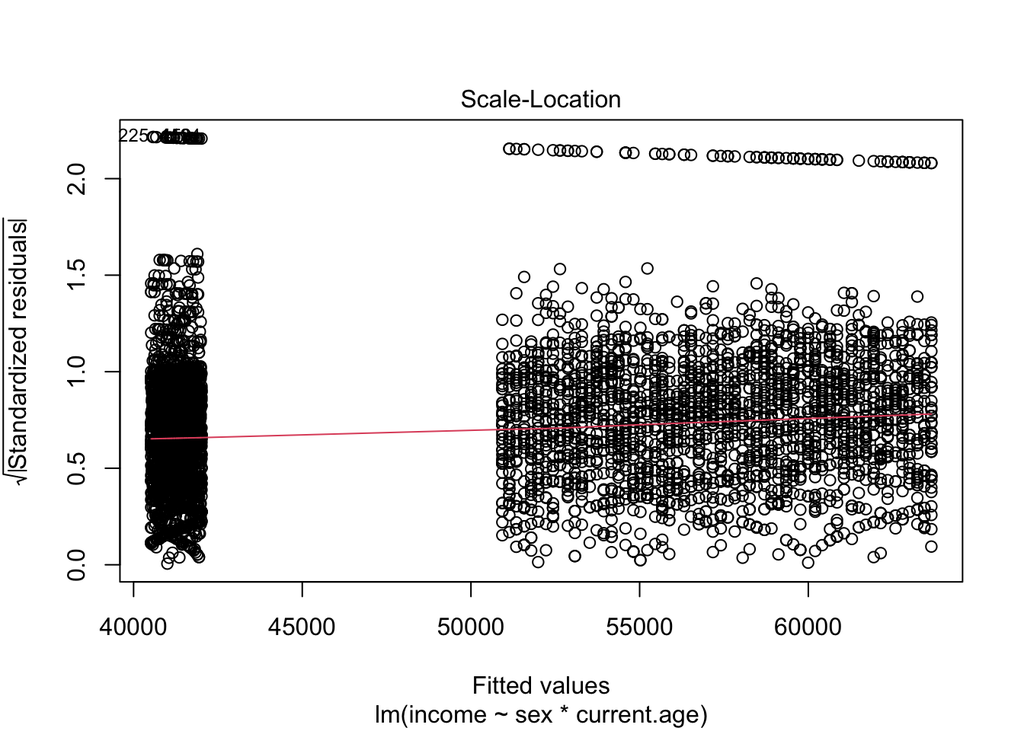

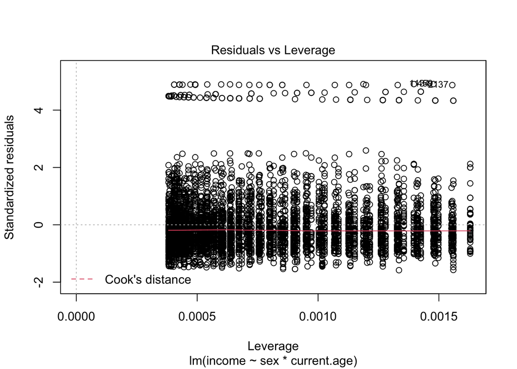

After generating plots to evaluate our linear model, we can see our Residuals vs Fitted plot, the points surround the red line in a fairly constant manner despite having a gap from about 42,500 to just above 50,000 which may suggest a linear model is inappropriate. The Normal Q-Q plot is potentially problematic because many of the values don’t fit the line at the extreme ends of the data, especially the high end. This may cause our p-values to be invalid. The scale location is very similar to the Residuals vs. Fitted plot which is concerning and may again suggest our model is not appropriate. The Residuals vs Leverage plot shows there are a few points in the data that are outliers (high leverage and residuals) skewing the model, but not too many. Overall, these charts suggest modeling income over sex interacted with age in a linear way may have some drawbacks. Further discrepancies in the correlation of age and gender may be experienced had the data for the top 2% of earners not been truncated, mostly in the male regression line. Considering that most of the incomes of the top 2% of earners are going to be older, male respondents, the regression line may be quite skewed when comparing age and income, resulting in a higher slope for the male interaction with age.

# Interaction of Race

To explore the interaction of race on the income gap between men and women, a t-test was performed on the percent differences within each racial group. The t-test provided insight into the mean percent difference, as well as provided a 95% confidence interval and determination of whether the difference was significant. The finding from that test can be seen below.

| Race | Income Gap (%) | Upper Bound (%) | Lower Bound (%) | P-Value | Significant? |
| --- | --- | --- | --- | --- | --- |
| Black | 17.878 | 27.202 | 8.553 | 0.000 | Yes |
| Hispanic | 36.704 | 45.115 | 28.293 | 0.000 | Yes |
| Mixed Race | 30.096 | 65.202 | -5.009 | 0.091 | No |
| Other | 32.640 | 38.512 | 26.767 | 0.000 | Yes |

From looking at the results above, males earned, on average, between 17.878% to 36.704% more than females in their respective racial groups. Additionally, it was apparent that the income gap was significant for all of the racial groups, except Mixed Race. While the results into the income gap are helpful, visualizing the results allowed insight to be derived into whether belonging to certain racial group exacerbates or mitigates the income gap.

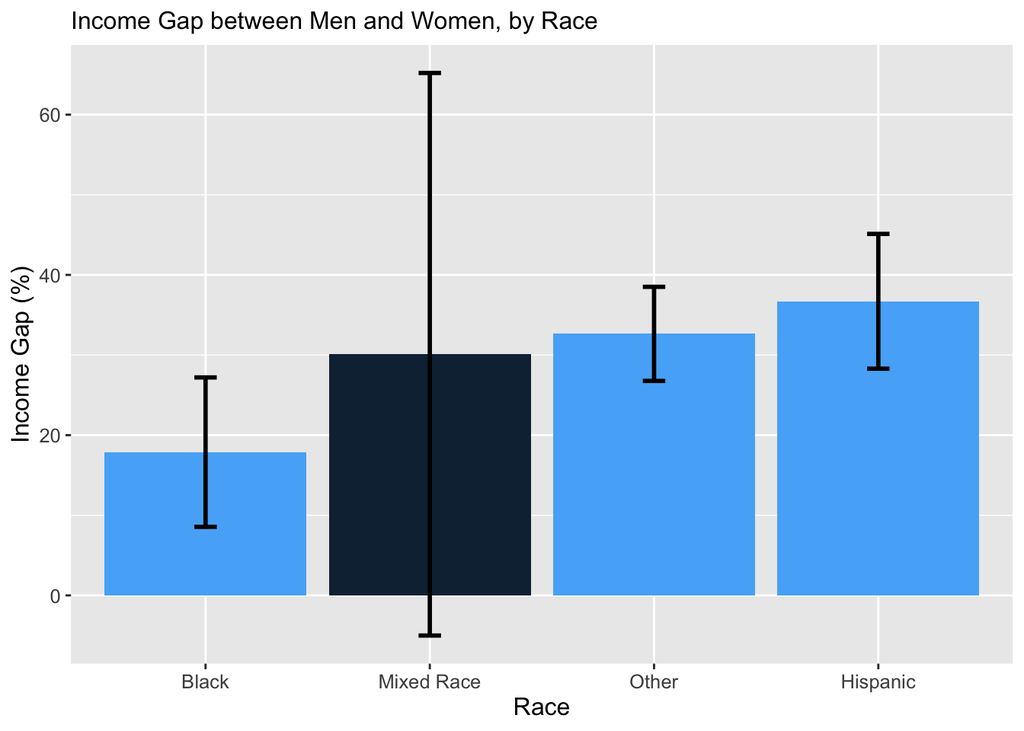

From looking at the bar graph, it appears that Black individuals had the lowest income gap, while Hispanic individuals had the highest income gap. Thus, we observe that being Black is a mitigating factor to the income gap, while being Hispanic is an exacerbating factor to the income gap. Once again, there may be discrepancies in the t-test, as the topcoded 2% values may affect the data, especially the “Other Race” category. This would result in a higher Income Gap Percentage for the category, meaning that being another race that is not Hispanic, Black, or Mixed will contribute to differences in income across genders.

# Interaction of Citizen Status

| Citizenship Status | Income Gap (%) | Upper Bound (%) | Lower Bound (%) | P-Value | Significant? |
| --- | --- | --- | --- | --- | --- |
| Citizen, Born in the U.S. | 32.222 | 37.134 | 27.309 | 0.000 | Yes |
| Unknown, Birthplace Undetermined | 28.511 | 44.520 | 12.502 | 0.001 | Yes |
| Unknown, Not Born in U.S. | 35.254 | 63.065 | 7.443 | 0.013 | Yes |

From looking at the results above, males earned, on average, between 28.510% to 35.253% more than females in their respective citizen status groups. Additionally, it was apparent that the income gap was significant for all of the citizen status groups. While the results into the income gap are helpful, visualizing the results allowed insight to be derived into whether belonging to certain citizen status group exacerbates or mitigates the income gap.

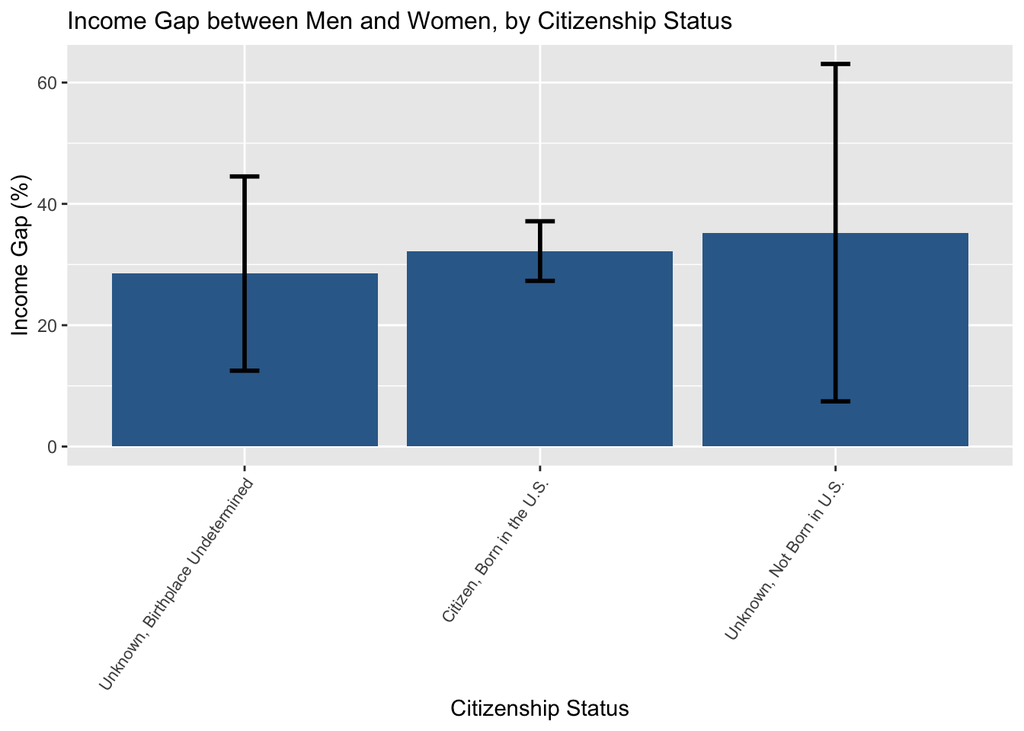

From looking at the bar graph, it appears that individuals with an unknown citizen status, and birthplace undetermined had the lowest income gap, while individuals with an unknown citizen status, and not born in the United States had the highest income gap. Thus, we observe that having unknown citizen status, and birthplace undetermined is a mitigating factor to the income gap, while having unknown citizen status, and not being born in the United States is an exacerbating factor to the income gap. The impact of truncated values of the 2% may also impact this t-test confidence interval, though the change would not be as defined as in the previous interactions, as the question posed in the survey will result in mostly U.S. citizens. Adding an extra point, even if it is a big outlier, will not skew the results much.

# Interaction of Household Net Worth

| Household Net Worth | Income Gap (%) | Upper Bound (%) | Lower Bound (%) | P-Value | Significant? |
| --- | --- | --- | --- | --- | --- |
| $108,000 to $159,999 | 23.988 | 39.138 | 8.838 | 0.002 | Yes |
| $160,000 to $289,999 | 41.182 | 55.286 | 27.079 | 0.000 | Yes |
| $18,000 to $30,999 | 26.152 | 42.115 | 10.189 | 0.001 | Yes |
| $3,000 to $7,999 | 28.872 | 43.582 | 14.161 | 0.000 | Yes |
| $31,000 to $48,999 | 34.786 | 48.788 | 20.783 | 0.000 | Yes |
| $49,000 to $72,999 | 32.929 | 47.916 | 17.942 | 0.000 | Yes |
| $73,000 to $107,999 | 43.401 | 59.260 | 27.541 | 0.000 | Yes |
| $8,000 to $17,999 | 33.234 | 47.294 | 19.174 | 0.000 | Yes |
| Less Than $3,000 | 31.565 | 49.299 | 13.831 | 0.001 | Yes |
| Over $290,000 | 17.220 | 33.635 | 0.806 | 0.040 | Yes |

From looking at the results above, males earned, on average, between 17.220% to 43.401% more than females in their respective household income groups. Additionally, it was apparent that the income gap was significant for all of the household income groups. While the results into the income gap are helpful, visualizing the results allowed insight to be derived into whether belonging to certain household income group exacerbates or mitigates the income gap.

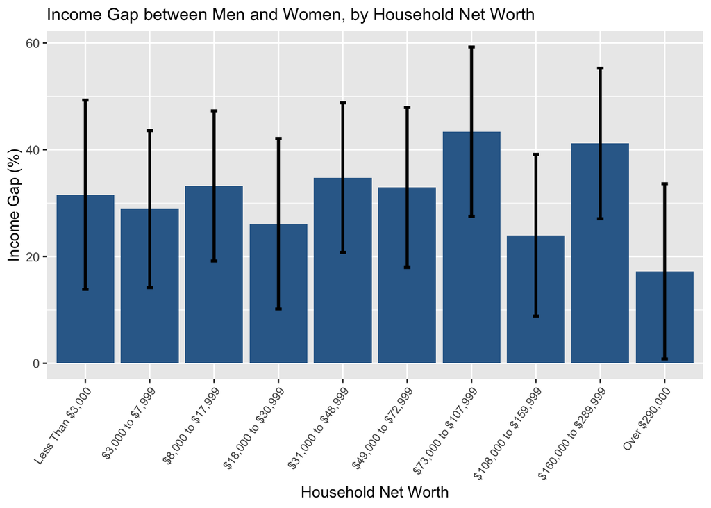

# Interaction of Days Religious Activity

| Days Religious Activity | Income Gap (%) | Upper Bound (%) | Lower Bound (%) | P-Value | Significant? |
| --- | --- | --- | --- | --- | --- |
| Multiple Days | 28.321 | 38.013 | 18.628 | 0 | Yes |
| No Days | 23.199 | 32.559 | 13.839 | 0 | Yes |
| One Day | 25.661 | 35.187 | 16.135 | 0 | Yes |

From looking at the results above, males earned, on average, between 23.199% to 28.321% more than females in their respective religious activity groups. Additionally, it was apparent that the income gap was significant for all of the religious activity groups. While the results into the income gap are helpful, visualizing the results allowed insight to be derived into whether belonging to certain religious activity group exacerbates or mitigates the income gap.

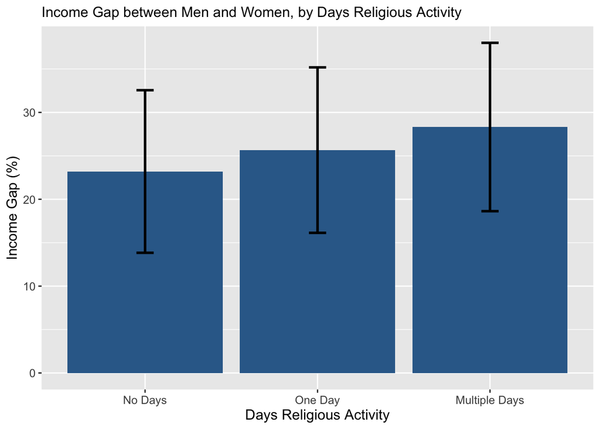

From looking at the bar graph, it appears that individuals attending no religious activity had the lowest income gap, while individuals attending multiple days of religious activity had the highest income gap. Thus, we observe that attending no religious activity is a mitigating factor to the income gap, while attending multiple days of religious activity is an exacerbating factor to the income gap. Without a clear connection of high earners and religion, it is indeterminable how the truncated 2% data will impact the results.

# Interaction of Biological Mother Birth Age

| Biological Mother Birth Age | Income Gap (%) | Upper Bound (%) | Lower Bound (%) | P-Value | Significant? |
| --- | --- | --- | --- | --- | --- |
| 19-21 | 30.982 | 39.081 | 22.884 | 0 | Yes |
| 22-24 | 31.794 | 40.896 | 22.693 | 0 | Yes |
| 24-27 | 37.725 | 48.087 | 27.363 | 0 | Yes |
| Over 27 | 24.435 | 36.032 | 12.839 | 0 | Yes |
| Under 19 | 34.621 | 45.185 | 24.057 | 0 | Yes |

From looking at the results above, males earned, on average, between 24.435% to 37.725% more than females in their respective biological mother’s age at first birth groups. Additionally, it was apparent that the income gap was significant for all of the biological mother’s age at first birth groups. While the results into the income gap are helpful, visualizing the results allowed insight to be derived into whether belonging to certain biological mother’s age at first birth group exacerbates or mitigates the income gap.

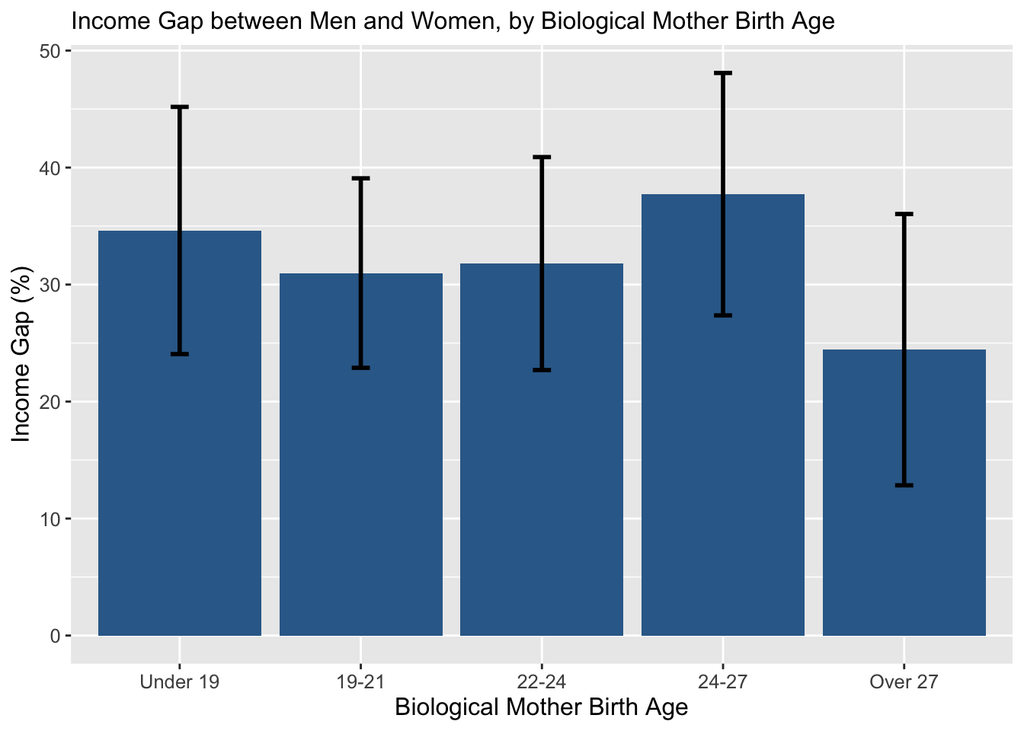

From looking at the bar graph, it appears that individuals with mother’s who were over 27 when they had their first child had the lowest income gap, while individuals with mother’s who were between 24 and 27 when they had their first child had the highest income gap. Thus, we observe that having a mother who was over 27 when they had their first child is a mitigating factor to the income gap, while having a mother who was between 24 and 27 when they had their first child is an exacerbating factor to the income gap. As previously stated, most people in the top percents of income earners will be men. Thus, excluding the true values and truncating the data will not skew the impact of a mother’s birth age, as this variable deals with women, not men.

# Interaction of Caretaker Relationship to Child

| Parent Relationship to Child | Income Gap (%) | Upper Bound (%) | Lower Bound (%) | P-Value | Significant? |
| --- | --- | --- | --- | --- | --- |
| Adoptive Parent(s) | -0.738 | 48.171 | -49.647 | 0.976 | No |
| Anything Else | 24.339 | 68.016 | -19.338 | 0.263 | No |
| Biological Father Only | 31.326 | 58.197 | 4.455 | 0.023 | Yes |
| Biological Mother Only | 27.908 | 36.331 | 19.486 | 0.000 | Yes |
| Both Biological Parents | 32.250 | 38.139 | 26.360 | 0.000 | Yes |
| Foster Parents | -22.319 | 80.078 | -124.716 | 0.625 | No |
| No Parents, Grandparents | 37.558 | 76.221 | -1.105 | 0.057 | No |
| No Parents, Other Relatives | 13.049 | 49.176 | -23.077 | 0.470 | No |
| Two Parents, Biological Father | 32.023 | 56.326 | 7.721 | 0.010 | Yes |
| Two Parents, Biological Mother | 33.114 | 45.756 | 20.472 | 0.000 | Yes |

From looking at the results above, males earned, on average, between 22.319% less to 37.558% more than females in their respective relationship to caretaker groups. Additionally, it was apparent that the income gap was significant for the relationship to caretaker groups with a biological parent, and not significant otherwise. While the results into the income gap are helpful, visualizing the results allowed insight to be derived into whether belonging to certain relationship to caretaker group exacerbates or mitigates the income gap.

[figure not shown]

From looking at the bar graph, it appears that individuals with biological Mother’s only had the lowest income gap, while individuals with two parents, biological Mother group had the highest income gap. However, from observing the overall table, it appears that having a biological parent in the household is an exacerbating factor, while not having a biological parent in the household is not significant. Once again, this will be indeterminate, as a top 2% income may not be associated with family status.

# Interaction of Biological Mother’s Education

| Biological Mother’s Education | Income Gap (%) | Upper Bound (%) | Lower Bound (%) | P-Value | Significant? |
| --- | --- | --- | --- | --- | --- |
| College | 21.251 | 31.448 | 11.053 | 0.000 | Yes |
| High School | 40.144 | 46.866 | 33.422 | 0.000 | Yes |
| No High School | 19.401 | 34.742 | 4.060 | 0.013 | Yes |
| Some College | 35.640 | 44.985 | 26.294 | 0.000 | Yes |
| Some High School | 32.521 | 43.218 | 21.823 | 0.000 | Yes |

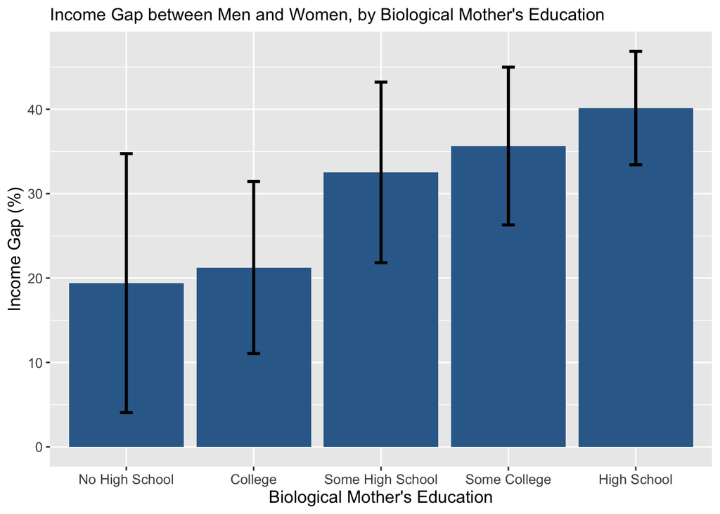

# Interaction of Biological Father’s Education

| Biological Fathers’s Education | Income Gap (%) | Upper Bound (%) | Lower Bound (%) | P-Value | Significant? |
| --- | --- | --- | --- | --- | --- |
| College | 28.883 | 39.149 | 18.617 | 0.000 | Yes |
| High School | 30.971 | 38.189 | 23.754 | 0.000 | Yes |
| No High School | 26.466 | 41.378 | 11.555 | 0.001 | Yes |
| Some College | 36.312 | 46.853 | 25.771 | 0.000 | Yes |
| Some High School | 38.519 | 51.538 | 25.500 | 0.000 | Yes |

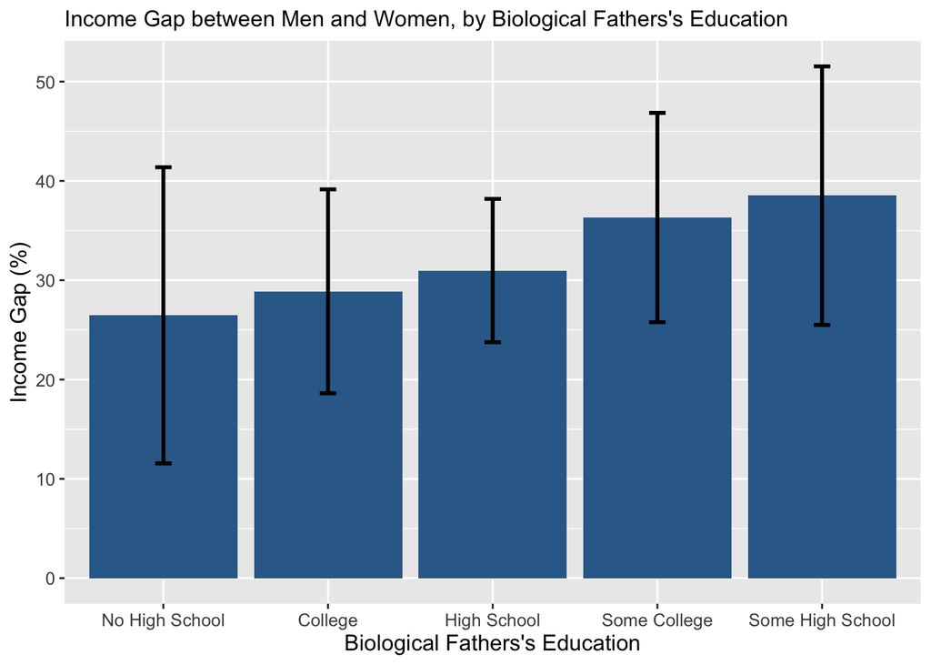

From looking at the bar graph, it appears that individuals with biological Fathers with no high school education had the lowest income gap, while individuals with biological Fathers with some high school education had the highest income gap. Thus, we observe that having a biological Father with no high school education is a mitigating factor to the income gap, while having a Father with some high school education is an exacerbating factor to the income gap. However, this warrants further exploration, and we assume the mitigating factor is instead a Father with a college education. The results are quite similar to the ones presented in the previous section. Thus, the fact that there is truncated data may not skew the results significantly.

# Interaction of Caretaker Mother’s Education

| Caretaker Mother’s Education | Income Gap (%) | Upper Bound (%) | Lower Bound (%) | P-Value | Significant? |
| --- | --- | --- | --- | --- | --- |
| College | 18.816 | 28.979 | 8.652 | 0.000 | Yes |
| High School | 41.463 | 48.418 | 34.508 | 0.000 | Yes |
| No High School | 19.723 | 35.152 | 4.294 | 0.012 | Yes |
| Some College | 33.248 | 42.524 | 23.972 | 0.000 | Yes |
| Some High School | 35.635 | 46.794 | 24.476 | 0.000 | Yes |

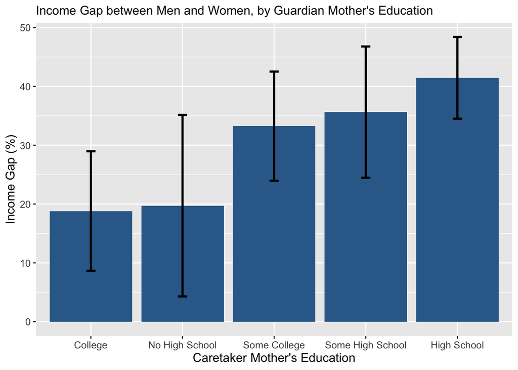

From looking at the bar graph, it appears that individuals with caretaker mothers with a college education had the lowest income gap, while individuals with caretaker mother’s with a high school education had the highest income gap. Thus, we observe that having a caretaker mother with a college education is a mitigating factor to the income gap, while having a caretaker mother with a high school education is an exacerbating factor to the income gap. The data may skew a bit more in this interaction if the income values were not topcoded due to the significance of college among guardians, which is also seen in the guardian/ caretaker father interaction. Nonetheless, the changes in results will still be trivial.

# Interaction of Guardian Father’s Education

| Guardian Father’s Education | Income Gap (%) | Upper Bound (%) | Lower Bound (%) | P-Value | Significant? |
| --- | --- | --- | --- | --- | --- |
| College | 29.245 | 39.863 | 18.628 | 0 | Yes |
| High School | 29.309 | 37.573 | 21.044 | 0 | Yes |
| No High School | 32.567 | 49.274 | 15.860 | 0 | Yes |
| Some College | 35.157 | 45.826 | 24.487 | 0 | Yes |
| Some High School | 43.853 | 60.004 | 27.703 | 0 | Yes |

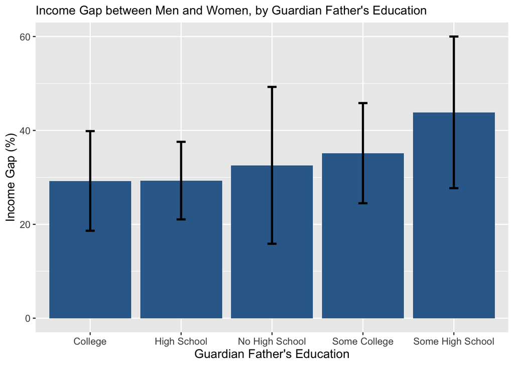

From looking at the bar graph, it appears that individuals with caretaker Fathers with a college education had the lowest income gap, while individuals with caretaker Fathers with some high school education had the highest income gap. Thus, we observe that having a caretaker Father with a college education is a mitigating factor to the income gap, while having a caretaker Father with some high school education is an exacerbating factor to the income gap. Finally, much like the previous interaction, the truncated 2% data will not significantly alter the results.

# Discussion

The findings clearly demonstrate that there is indeed a statistically significant discrepancy between income across genders. However, some limitations to this model exist. The first limitation is ignoring the respondents’ grades and drug usage - personal choices rather than imposed upon them. Furthermore, unidentified confounding variables may affect the overall interaction between variables, leading to different t-values and thus different confidence intervals. Finally, the censoring of top 2% earner data may skew the results, resulting in further differences, meaning that the findings of this paper undermine the true income gap in the United States across gender.

The overall confidence in this paper’s findings is very high. Though the limited experience of the group members may influence the accuracy of the model, the conclusions presented by the data are mostly statistically significant, making the conclusions quite believable and reputable.

[^1]: Yavorsky JE, Keister LA, Qian Y, Nau M. Women in the One Percent: Gender Dynamics in Top Income Positions. American Sociological Review. 2019;84(1):54-81. doi:10.1177/0003122418820702